# Self-Driving Car Engineer Nanodegree

## Project: Build a Traffic Sign Recognition Classifier

In this notebook, a template is provided for you to implement your functionality in stages which is required to successfully complete this project. If additional code is required that cannot be included in the notebook, be sure that the Python code is successfully imported and included in your submission, if necessary. Sections that begin with **'Implementation'** in the header indicate where you should begin your implementation for your project. Note that some sections of implementation are optional, and will be marked with **'Optional'** in the header.

In addition to implementing code, there will be questions that you must answer which relate to the project and your implementation. Each section where you will answer a question is preceded by a **'Question'** header. Carefully read each question and provide thorough answers in the following text boxes that begin with **'Answer:'**. Your project submission will be evaluated based on your answers to each of the questions and the implementation you provide.

> **Note:** Code and Markdown cells can be executed using the **Shift + Enter** keyboard shortcut. In addition, Markdown cells can be edited by typically double-clicking the cell to enter edit mode.

## Step 0: Load The Data

```python
# Load pickled data
import pickle

# TODO: Fill this in based on where you saved the training and testing data

training_file = 'GTSRB/train.p'
testing_file = 'GTSRB/test.p'

with open(training_file, mode='rb') as f:
    train = pickle.load(f)
with open(testing_file, mode='rb') as f:
    test = pickle.load(f)

X_train, y_train = train['features'], train['labels']
X_test, y_test = test['features'], test['labels']
```

## Step 1: Dataset Summary & Exploration

The pickled data is a dictionary with 4 key/value pairs:

- `'features'` is a 4D array containing raw pixel data of the traffic sign images, (num examples, width, height, channels).
- `'labels'` is a 1D array containing the label/class id of the traffic sign. The file `signnames.csv` contains id -> name mappings for each id.
- `'sizes'` is a list containing tuples, (width, height) representing the the original width and height the image.
- `'coords'` is a list containing tuples, (x1, y1, x2, y2) representing coordinates of a bounding box around the sign in the image. **THESE COORDINATES ASSUME THE ORIGINAL IMAGE. THE PICKLED DATA CONTAINS RESIZED VERSIONS (32 by 32) OF THESE IMAGES**

Complete the basic data summary below.

```python
### Replace each question mark with the appropriate value.

# TODO: Number of training examples
n_train = train['labels'].shape[0]

# TODO: Number of testing examples.
n_test = test['labels'].shape[0]

# TODO: What's the shape of an traffic sign image?
image_shape = train['features'].shape[1:3]

# TODO: How many unique classes/labels there are in the dataset.
file = open("signnames.csv")
n_classes = len(set(y_test))

print("Number of training examples =", n_train)
print("Number of testing examples =", n_test)
print("Image data shape =", image_shape)
print("Number of classes =", n_classes)
```

```
Number of training examples = 39209
Number of testing examples = 12630
Image data shape = (32, 32)
Number of classes = 43
```

Visualize the German Traffic Signs Dataset using the pickled file(s). This is open ended, suggestions include: plotting traffic sign images, plotting the count of each sign, etc.

The [Matplotlib](http://matplotlib.org/) [examples](http://matplotlib.org/examples/index.html) and [gallery](http://matplotlib.org/gallery.html) pages are a great resource for doing visualizations in Python.

**NOTE:** It's recommended you start with something simple first. If you wish to do more, come back to it after you've completed the rest of the sections.

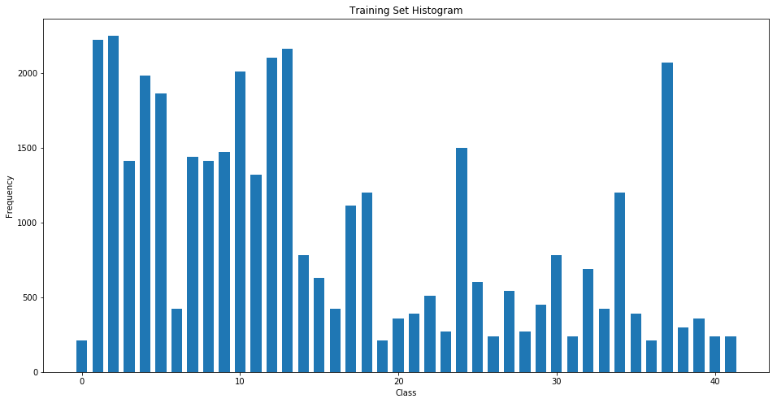

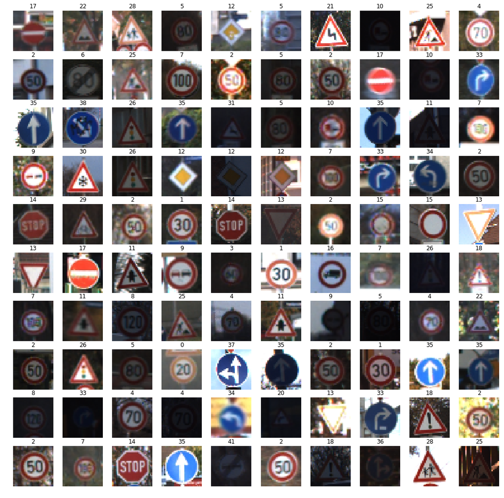

```python
### Data exploration visualization goes here.
### Feel free to use as many code cells as needed.
import numpy as np
import matplotlib.pyplot as plt
import matplotlib.gridspec as gridspec
import random

# Visualizations will be shown in the notebook.
%matplotlib inline

def display_images(X,y):
# displays 100 images of input set along with labels

    index=random.sample(range(0, len(X)), 100)

    gs = gridspec.GridSpec(10, 10)
    gs.update(wspace=0.1, hspace=0.1)
    plt.figure(figsize=(18,18))
    for i in range(100):
        ax = plt.subplot(gs[i])
        ax.set_xticklabels([])
        ax.set_yticklabels([])
        ax.set_aspect('equal')

        image = X[index][i].squeeze()

        plt.subplot(10,10,i+1)
        plt.imshow(image)
        plt.title(str(y[index][i]))
        plt.axis('off')

    plt.show()


hist1, bins1 = np.histogram(train['labels'], bins=43)
width = 0.7 * (bins1[1] - bins1[0])
center1 = (bins1[:-1] + bins1[1:]) // 2
plt.figure(figsize=(16,8))
plt.bar(center1, hist1, align='center', width=width)
plt.title("Training Set Histogram")
plt.xlabel("Class")
plt.ylabel("Frequency")
plt.show()


display_images(X_train,y_train)
```

## Step 2: Design and Test a Model Architecture

Design and implement a deep learning model that learns to recognize traffic signs. Train and test your model on the [German Traffic Sign Dataset](http://benchmark.ini.rub.de/?section=gtsrb&subsection=dataset).

There are various aspects to consider when thinking about this problem:

- Neural network architecture
- Play around preprocessing techniques (normalization, rgb to grayscale, etc)
- Number of examples per label (some have more than others).
- Generate fake data.

Here is an example of a [published baseline model on this problem](http://yann.lecun.com/exdb/publis/pdf/sermanet-ijcnn-11.pdf). It's not required to be familiar with the approach used in the paper but, it's good practice to try to read papers like these.

**NOTE:** The LeNet-5 implementation shown in the classroom at the end of the CNN lesson is a solid starting point. You'll have to change the number of classes and possibly the preprocessing, but aside from that it's plug and play!

### Implementation

Use the code cell (or multiple code cells, if necessary) to implement the first step of your project. Once you have completed your implementation and are satisfied with the results, be sure to thoroughly answer the questions that follow.

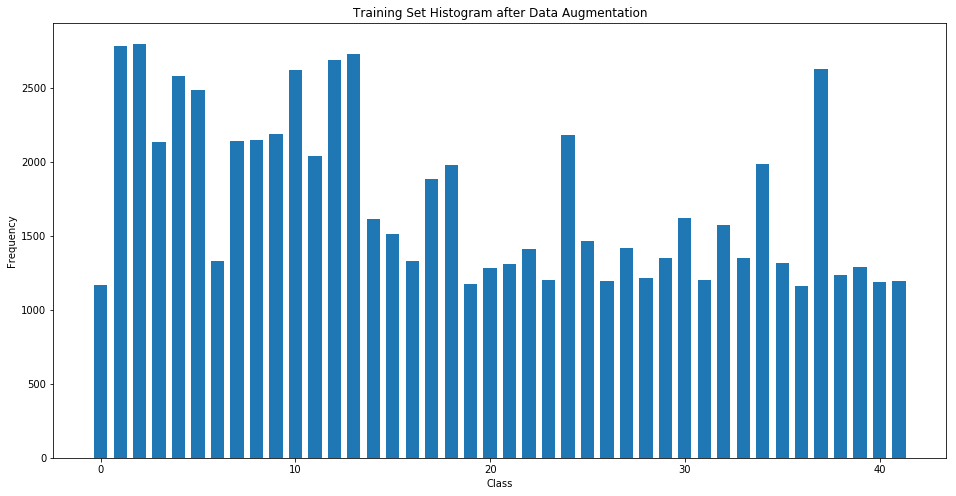

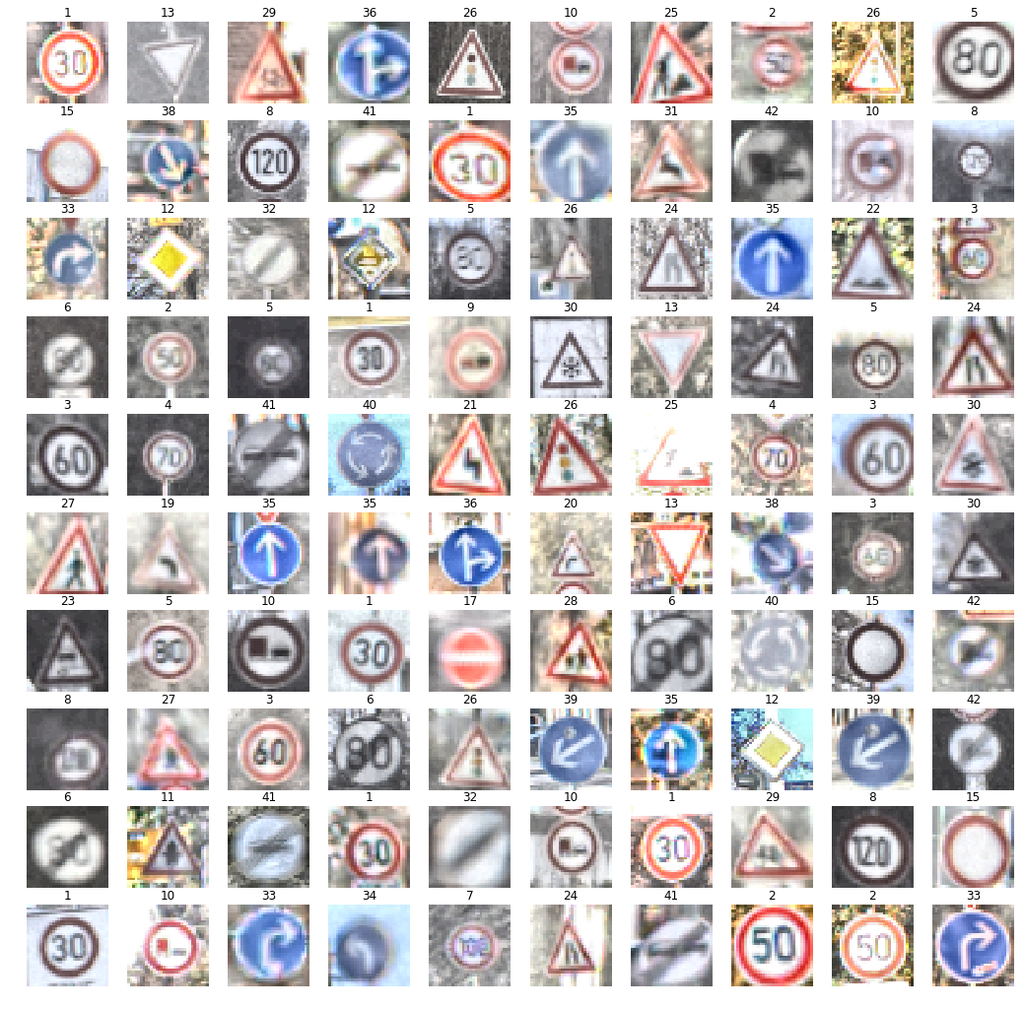

```python
import cv2
from sklearn.utils import shuffle
from sklearn.model_selection import train_test_split

### Split the data into training/validation/testing sets here.

X_train,X_validation,y_train,y_validation = train_test_split(X_train,y_train,test_size=0.2,random_state=0)

def color_normalization(X):

    X_clahe = np.zeros_like(X)

    for i in range(X.shape[0]):

        image = X[i]

        image_YUV = cv2.cvtColor(image, cv2.COLOR_RGB2YUV)

        clahe = cv2.createCLAHE(clipLimit=2, tileGridSize=(4,4))

        image_YUV[:,:,0] = clahe.apply(image_YUV[:,:,0])

        X_clahe[i] = cv2.cvtColor(image_YUV, cv2.COLOR_YUV2RGB)

    return X_clahe

def transform_image(image,distort = None,rot_angle = None):

    rows,cols = image.shape[:2]

    #rand_ang = np.random.uniform(-rot_angle, rot_angle)

    #rot_mat = cv2.getRotationMatrix2D((cols/2, rows/2), rand_ang, 1.0)

    #image = cv2.warpAffine(image, rot_mat, (cols,rows))


    pivot_hor = cols - distort
    pivot_ver = rows - distort

    pts1 = np.float32([[distort + np.random.randint(-distort+1,distort-1),distort + np.random.randint(-distort+1,distort-1)],
                       [pivot_hor + np.random.randint(-distort+1,distort-1),distort + np.random.randint(-distort+1,distort-1)],
                       [distort + np.random.randint(-distort+1,distort-1),pivot_ver + np.random.randint(-distort+1,distort-1)],
                       [pivot_hor + np.random.randint(-distort+1,distort-1),pivot_ver + np.random.randint(-distort+1,distort-1)]])
    pts2 = np.float32([[0,0],[cols,0],[0,rows],[cols,rows]])

    M = cv2.getPerspectiveTransform(pts1,pts2)

    result = cv2.warpPerspective(image,M,(cols,rows))

    return result

### Generate additional data (OPTIONAL!)

class_bincount = np.bincount(y_train)

for i in range(n_classes):
    new_features, new_labels = [], []
    features = X_train[np.where(y_train == i)]
    add_count = 1000  # the number of adding images
    for j in range(add_count):
        rand_img = np.random.randint(class_bincount[i])
        new_features.append(transform_image(features[rand_img],np.random.randint(2,5)))
        new_labels.append(i)

    X_train = np.append(X_train, new_features, axis=0)
    y_train = np.append(y_train, new_labels, axis=0)

del new_features, new_labels

# Each classes' train dataset size after balancing
hist1, bins1 = np.histogram(y_train, bins=43)
width = 0.7 * (bins1[1] - bins1[0])
center1 = (bins1[:-1] + bins1[1:]) // 2
plt.figure(figsize=(16,8))
plt.bar(center1, hist1, align='center', width=width)
plt.title("Training Set Histogram after Data Augmentation")
plt.xlabel("Class")
plt.ylabel("Frequency")
plt.show()

### Preprocess the data here.

X_train = color_normalization(X_train)
X_validation = color_normalization(X_validation)
X_test = color_normalization(X_test)

X_train, y_train = shuffle(X_train, y_train)

display_images(X_train,y_train)
```

### Question 1

*Describe how you preprocessed the data. Why did you choose that technique?*

**Answer:**

The dataset consists of 43 classes with a distribution as shown in the first histogram. Traffic sign images are captured under varied lighting and perspectives, some are even blurred or occluded. This calls for designing a robust system for classification purposes. The images were preprocessed by first converting into the YUV colorspace, then using the Contrast Limited Adaptive Histogram Equalization (CLAHE) technique on the Y channel and then converting back to the RGB colorspace. Y, being the luma component (brightness), was equalized across every picture as the exposure varies starkly across the entire dataset. This difference in exposure affects the classification performance if not accounted for. The CLAHE algorithm was chosen as it does histogram equalization in patches and adaptively compensates for regions where intesity varies widely (as compared to normal histogram equalization which doesn't work well in images with both overexposed and underexposed regions). The dataset was not converted to grayscale as color is a prominent feature of traffic signs and I wanted the network to associate color with different signs.

```python
### Define your architecture here.
### Feel free to use as many code cells as needed.

import tensorflow as tf

EPOCHS = 50
BATCH_SIZE = 256

'''
def batch_normalization_custom(x,layer,epsilon=1e-12):
    if layer == 'conv':
        batch_mean, batch_var = tf.nn.moments(x,[0,1,2])
    elif layer == 'full':
        batch_mean, batch_var = tf.nn.moments(x,[0])
    else:
        raise('Specify correct layer')

    return tf.nn.batch_normalization(x,batch_mean,batch_var,None,None,epsilon)
'''

def batch_normalization_custom(x,is_training):
    return tf.contrib.layers.batch_norm(x, is_training=is_training, updates_collections = None, center=True,
                                        scale=True,epsilon=1e-12,decay=0.9,reuse=False, trainable=True)


def dropout_custom(x,keep,is_training):
    if is_training == True:
        return tf.nn.dropout(fc1, keep)
    else:
        return x
```

### Question 2

*Describe how you set up the training, validation and testing data for your model. **Optional**: If you generated additional data, how did you generate the data? Why did you generate the data? What are the differences in the new dataset (with generated data) from the original dataset?*

```python
from tensorflow.contrib.layers import flatten

def DCNN(x,is_training):
    # Arguments used for tf.truncated_normal, randomly defines variables for the weights and biases for each layer
    mu = 0
    sigma = 0.1
    epsilon=1e-12

    # TODO: Layer 1: Convolutional. Input = 32x32x3. Output = 30x30x32.
    conv1_W = tf.Variable(tf.truncated_normal(shape=(3,3,3,32),mean=mu,stddev=sigma))
    conv1_b = tf.Variable(tf.zeros(32))
    conv1 = tf.nn.conv2d(x,conv1_W, strides = [1,1,1,1], padding = 'VALID') + conv1_b

    # TODO: Batch normalization and Activation.

    conv1 = batch_normalization_custom(conv1,is_training)

    conv1 = tf.nn.relu6(conv1)

    # TODO: Layer 2: Convolutional. Input = 30x30x32. Output = 28x28x64.
    conv2_W = tf.Variable(tf.truncated_normal(shape=(3,3,32,64),mean=mu,stddev=sigma))
    conv2_b = tf.Variable(tf.zeros(64))
    conv2 = tf.nn.conv2d(conv1,conv2_W, strides = [1,1,1,1], padding = 'VALID') + conv2_b

    # TODO: Batch normalization and Activation.

    conv2 = batch_normalization_custom(conv2,is_training)

    conv2 = tf.nn.relu6(conv2)

    # TODO: Pooling. Input = 28x28x64. Output = 14x14x64.

    conv2 = tf.nn.avg_pool(conv2,ksize=[1,2,2,1],strides=[1,2,2,1],padding='VALID')

    conv2 = batch_normalization_custom(conv2,is_training)

    # TODO: Layer 3: Convolutional. Input = 14x14x64. Output = 12x12x128.

    conv3_W = tf.Variable(tf.truncated_normal(shape=(3, 3, 64, 128), mean = mu, stddev = sigma))
    conv3_b = tf.Variable(tf.zeros(128))
    conv3   = tf.nn.conv2d(conv2, conv3_W, strides=[1, 1, 1, 1], padding='VALID') + conv3_b

    # TODO: Batch normalization and Activation.

    conv3 = batch_normalization_custom(conv3,is_training)

    conv3 = tf.nn.relu6(conv3)

    # TODO: Layer 4: Convolutional. Input = 12x12x128. Output = 10x10x256.

    conv4_W = tf.Variable(tf.truncated_normal(shape=(3, 3, 128, 256), mean = mu, stddev = sigma))
    conv4_b = tf.Variable(tf.zeros(256))
    conv4   = tf.nn.conv2d(conv3, conv4_W, strides=[1, 1, 1, 1], padding='VALID') + conv4_b

    # TODO: Batch normalization and Activation.

    conv4 = batch_normalization_custom(conv4,is_training)

    conv4 = tf.nn.relu6(conv4)

    # TODO: Layer 5: Convolutional. Input = 10x10x256. Output = 8x8x512.

    conv5_W = tf.Variable(tf.truncated_normal(shape=(3, 3, 256, 512), mean = mu, stddev = sigma))
    conv5_b = tf.Variable(tf.zeros(512))
    conv5   = tf.nn.conv2d(conv4, conv5_W, strides=[1, 1, 1, 1], padding='VALID') + conv5_b

    # TODO: Batch normalization and Activation.

    conv5 = batch_normalization_custom(conv5,is_training)

    conv5 = tf.nn.relu6(conv5)

    # TODO: Pooling. Input = 8x8x512. Output = 4x4x512.

    conv5 = tf.nn.avg_pool(conv5, ksize=[1, 2, 2, 1], strides=[1, 2, 2, 1], padding='VALID')

    conv5 = batch_normalization_custom(conv5,is_training)

    # TODO: Flatten. Input = 4x4x512. Output = 8192.

    fc0 = flatten(conv5)

    # TODO: Layer 5: Fully Connected. Input = 8192. Output = 1024.

    fc1_W = tf.Variable(tf.truncated_normal(shape=(8192,1024), mean = mu, stddev = sigma))
    fc1_b = tf.Variable(tf.zeros(1024))
    fc1 = tf.matmul(fc0,fc1_W)+fc1_b

    # TODO: Batch normalization and Activation.

    fc1 = batch_normalization_custom(fc1,is_training)

    fc1 = tf.nn.relu6(fc1)

    fc1 = dropout_custom(fc1, 0.5, is_training)

    # TODO: Layer 6: Fully Connected. Input = 1024. Output = 256.

    fc2_W  = tf.Variable(tf.truncated_normal(shape=(1024, 256), mean = mu, stddev = sigma))
    fc2_b  = tf.Variable(tf.zeros(256))
    fc2    = tf.matmul(fc1, fc2_W) + fc2_b

    # TODO: Batch normalization and Activation.

    fc2 = batch_normalization_custom(fc2,is_training)

    fc2 = tf.nn.relu6(fc2)

    fc2 = dropout_custom(fc2, 0.8, is_training)

    # TODO: Layer 7: Fully Connected. Input = 256. Output = 43.

    fc3_W  = tf.Variable(tf.truncated_normal(shape=(256, 43), mean = mu, stddev = sigma))
    fc3_b  = tf.Variable(tf.zeros(43))
    logits = tf.matmul(fc2, fc3_W) + fc3_b

    L2_loss = tf.nn.l2_loss(fc3_W)

    return logits, L2_loss
```

### Question 3

*What does your final architecture look like? (Type of model, layers, sizes, connectivity, etc.) For reference on how to build a deep neural network using TensorFlow, see Deep Neural Network in TensorFlow from the classroom.*

**Answer:**

A Deep Convolutional Neural Network (DCNN) architecture was designed. The details of the architecture are given below:

## Input

The DCNN architecture accepts a 32x32x3 image as input

### Architecture

**Layer 1: Convolutional 1**: Output - 30x30x32, Filter Size - 3x3

**Batch Normalization**

**Activation**: Relu6

**Layer 2: Convolutional 2**: Output - 28x28x64, Filter Size - 3x3

**Batch Normalization**

**Activation**: Relu6

**Layer 3: Convolutional 3**: Output - 12x12x128, Filter Size - 3x3

**Batch Normalization**

**Activation**: Relu6

**Layer 4: Convolutional 4**: Output - 10x10x256, Filter Size - 3x3

**Batch Normalization**

**Activation**: Relu6

**Layer 5: Convolutional 5**: Output - 8x8x512, Filter Size - 3x3

**Batch Normalization**

**Activation**: Relu6

**Average Pooling**: Output - 4x4x512

**Batch Normalization**

**Flatten**: Output - 8192

**Layer 6: Fully Connected 1**:Output - 1024

**Batch Normalization**

**Activation**: Relu6

**Dropout**: Keep Probability = 0.5

**Layer 7: Fully Connected 2**: Output - 256

**Batch Normalization**

**Activation**: Relu6

**Dropout**: Keep Probability = 0.8

**Layer 8: Fully Connected 3**: Output - 43

### Output

The output is 43 logits which are further processed

```python
### Train your model here.
### Feel free to use as many code cells as needed.

x = tf.placeholder(tf.float32, (None, 32, 32, 3))
y = tf.placeholder(tf.int32, (None))
is_training = tf.placeholder(tf.bool, name='MODE')
one_hot_y = tf.one_hot(y, 43)



rate = 0.001
beta = 1e-5

logits, L2_loss = DCNN(x,is_training)
cross_entropy = tf.nn.softmax_cross_entropy_with_logits(logits, one_hot_y)
loss_operation = tf.reduce_mean(cross_entropy) + beta*L2_loss
optimizer = tf.train.AdamOptimizer(learning_rate = rate)
training_operation = optimizer.minimize(loss_operation)


correct_prediction = tf.equal(tf.argmax(logits, 1), tf.argmax(one_hot_y, 1))
accuracy_operation = tf.reduce_mean(tf.cast(correct_prediction, tf.float32))
saver = tf.train.Saver()

def evaluate(X_data, y_data, mode):
    num_examples = len(X_data)
    total_accuracy = 0
    sess = tf.get_default_session()
    for offset in range(0, num_examples, BATCH_SIZE):
        batch_x, batch_y = X_data[offset:offset+BATCH_SIZE], y_data[offset:offset+BATCH_SIZE]
        accuracy = sess.run(accuracy_operation, feed_dict={x: batch_x, y: batch_y, is_training:mode})
        total_accuracy += (accuracy * len(batch_x))
    return total_accuracy / num_examples



with tf.Session() as sess:
    sess.run(tf.global_variables_initializer())
    num_examples = len(X_train)

    print("Training...")
    print()
    for i in range(EPOCHS):
        X_train, y_train = shuffle(X_train, y_train)
        for offset in range(0, num_examples, BATCH_SIZE):
            end = offset + BATCH_SIZE
            batch_x, batch_y = X_train[offset:end], y_train[offset:end]
            sess.run(training_operation, feed_dict={x: batch_x, y: batch_y, is_training:True})

        train_accuracy = evaluate(X_train, y_train, mode=True)
        validation_accuracy = evaluate(X_validation, y_validation, mode=False)
        print("EPOCH {} ...".format(i+1))
        print("Training Accuracy = {:.3f}".format(train_accuracy))
        print("Validation Accuracy = {:.3f}".format(validation_accuracy))
        print()

        if validation_accuracy > 0.998:
            saver.save(sess, 'dcnn')
            print("Model saved")
```

```
Training...

EPOCH 1 ...
Training Accuracy = 0.997
Validation Accuracy = 0.995

EPOCH 2 ...
Training Accuracy = 0.998
Validation Accuracy = 0.995

EPOCH 3 ...
Training Accuracy = 0.999
Validation Accuracy = 0.996

EPOCH 4 ...
Training Accuracy = 1.000
Validation Accuracy = 0.997

EPOCH 5 ...
Training Accuracy = 0.999
Validation Accuracy = 0.997

EPOCH 6 ...
Training Accuracy = 0.997
Validation Accuracy = 0.994

EPOCH 7 ...
Training Accuracy = 0.999
Validation Accuracy = 0.996

EPOCH 8 ...
Training Accuracy = 0.998
Validation Accuracy = 0.997

EPOCH 9 ...
Training Accuracy = 1.000
Validation Accuracy = 0.997

EPOCH 10 ...
Training Accuracy = 0.999
```

[output cut: 184 more lines]

```
EPOCH 48 ...
Training Accuracy = 1.000
Validation Accuracy = 0.999

Model saved
EPOCH 49 ...
Training Accuracy = 1.000
Validation Accuracy = 0.999

Model saved
EPOCH 50 ...
Training Accuracy = 1.000
Validation Accuracy = 0.999

Model saved
```

```python
with tf.Session() as sess:
    saver.restore(sess, tf.train.latest_checkpoint('.'))

    test_accuracy = evaluate(X_test, y_test, mode=False)
    print("Test Accuracy = {:.3f}".format(test_accuracy))
```

```
Test Accuracy = 0.990
```

### Question 4

*How did you train your model? (Type of optimizer, batch size, epochs, hyperparameters, etc.)*

### Question 5

*What approach did you take in coming up with a solution to this problem? It may have been a process of trial and error, in which case, outline the steps you took to get to the final solution and why you chose those steps. Perhaps your solution involved an already well known implementation or architecture. In this case, discuss why you think this is suitable for the current problem.*

**Answer:**

## Step 3: Test a Model on New Images

Take several pictures of traffic signs that you find on the web or around you (at least five), and run them through your classifier on your computer to produce example results. The classifier might not recognize some local signs but it could prove interesting nonetheless.

You may find `signnames.csv` useful as it contains mappings from the class id (integer) to the actual sign name.

### Implementation

Use the code cell (or multiple code cells, if necessary) to implement the first step of your project. Once you have completed your implementation and are satisfied with the results, be sure to thoroughly answer the questions that follow.

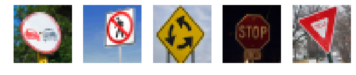

```python
### Load the images and plot them here.
### Feel free to use as many code cells as needed.

import matplotlib.image as mpimg


new_sign = ['no-overtaking.jpg', 'no-pedestrian.png', 'roundabout.jpg', 'stop.jpg', 'yield.jpg']

test_images = []

for name in new_sign:
    image = mpimg.imread('./test signs/' + name)
    image = cv2.resize(image,(32,32),interpolation = cv2.INTER_AREA)
    test_images.append(image)



gs = gridspec.GridSpec(1, 5)
gs.update(wspace=0.1, hspace=0.1)
plt.figure(figsize=(12,5))
for i in range(5):
    ax = plt.subplot(gs[i])
    ax.set_xticklabels([])
    ax.set_yticklabels([])
    ax.set_aspect('equal')

    image = test_images[i].squeeze()

    plt.subplot(1,5,i+1)
    plt.imshow(image)
    plt.axis('off')
```

### Question 6

*Choose five candidate images of traffic signs and provide them in the report. Are there any particular qualities of the image(s) that might make classification difficult? It could be helpful to plot the images in the notebook.*

**Answer:**

Five candidate images are plotted above. Each image would test the robustness of the network. The first image is a 'no overtaking' or 'no passing' sign that is weathered and even dented. The second image doens't belong to the dataset but is similar to the 'pedestrians' sign, however, it has square boundaries and is crossed out. The third image is reall tricky for the system as it's actually that of a 'roundabout' but is diamond shaped and differently colored than the one in the dataset. The fourth picture is that of a 'stop' sign at night with an underwriting. The fifth image is that of a 'yeild' but is rotated considerably and has yield written on it.

[output not shown]

[figure not shown]

[output not shown]

[figure not shown]

[output not shown]

[figure not shown]

[output not shown]

[figure not shown]

[output not shown]

[figure not shown]

[output not shown]

```python
### Run the predictions and visualize the softmax probabilities here.
### Feel free to use as many code cells as needed

import csv

with tf.Session() as sess:
    saver.restore(sess, tf.train.latest_checkpoint('.'))

    with open('signnames.csv', mode='r') as infile:
        reader = csv.reader(infile)
        sign_name = dict((rows[0],rows[1]) for rows in reader)

    probability = sess.run(tf.nn.softmax(logits), feed_dict={x:test_images, is_training:False})

    values, indices = sess.run(tf.nn.top_k(tf.nn.softmax(logits), k=5), feed_dict={x:test_images, is_training:False})

    for i in range(5):
        print()
        print()
        print(new_sign[i][0:-4])
        print()
        plt.figure(figsize=(12, 3))
        plt.subplot(1,2,1)
        plt.imshow(test_images[i])
        plt.axis('off')
        plt.subplot(1,2,2)
        plt.plot(np.arange(43), probability[i])
        plt.xlabel('Sign Label')
        plt.ylabel('Softmax Probability')
        for j in range(5):
            print("Label : {}\t Accuracy {:.3f}%".format(sign_name[str(indices[i,j])], values[i,j] * 100))
        plt.show()
```

### Question 7

*Is your model able to perform equally well on captured pictures when compared to testing on the dataset? The simplest way to do this check the accuracy of the predictions. For example, if the model predicted 1 out of 5 signs correctly, it's 20% accurate.*

**Answer:**

As seen above, accuracy is 60% on the five images, two of which don't even belong to the dataset. Unsuprisingly, the network fails to identify the diamond-shaped 'roundabout' and the "round-square" 'no-pedestrians' sign. However, the network classifies the remaining images (even with slight twists) with a high probability.

### Question 8

*Use the model's softmax probabilities to visualize the **certainty** of its predictions, [`tf.nn.top_k`](https://www.tensorflow.org/versions/r0.12/api_docs/python/nn.html#top_k) could prove helpful here. Which predictions is the model certain of? Uncertain? If the model was incorrect in its initial prediction, does the correct prediction appear in the top k? (k should be 5 at most)*

**Answer:**

The only image the network is ambivalent about is the "round-square" 'no-pedestrians' sign, the rest having more than 90% probabilities for one single class, although the diamond-shaped 'roundabout' prediction is incorrect. For the the 'roundabout' the network predicts that it is a 'priority road sign' which is also diamond shaped and has a yellow color. This is thus understandable in that the shape of the sign has to be consistent for correct classification. The network's predictions for round-square crossed 'no-pedestrains' sign are even more interesting. The top-2 results are for speed limits which's evident because of the round red circle. The third prediction is that of a 'priority road' as the network has detected the square or rotated diamond shape. The next two predictions are because of the occluded black markings in the centre which look like those of 'general caution' and 'road work'. This example makes it clear that the network has truly learnt to break down traffic signs into individual features just like humans, which is remarkable.